# 7_EDA

Andrea Pedot

18/2/2021

### Exercises

1. Explore the distribution of each of the `x`, `y`, and `z` variables in `diamonds`. What do you learn? Think about a diamond and how you might decide which dimension is the length, width, and depth.

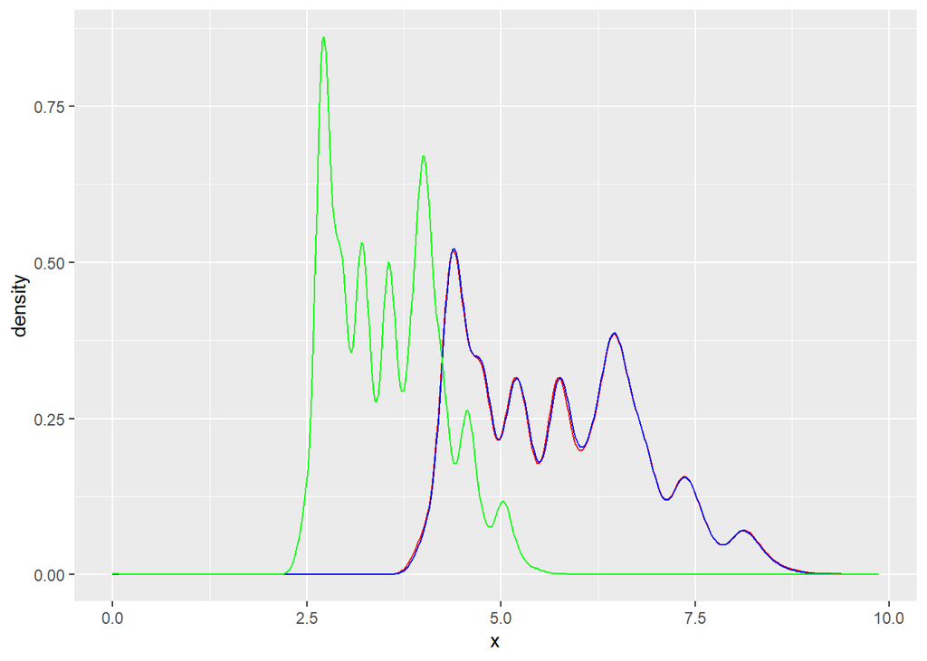

```r
fdiamonds <- filter(diamonds, z < 10 & y < 10 & x < 10)

ggplot(fdiamonds) +
  geom_density( aes( x = x ), color = "red") +
  geom_density( aes( x = y ), color = "blue") +
  geom_density( aes( x = z ), color = "green")
```

1. Explore the distribution of `price`. Do you discover anything unusual or surprising? (Hint: Carefully think about the `binwidth` and make sure you try a wide range of values.)

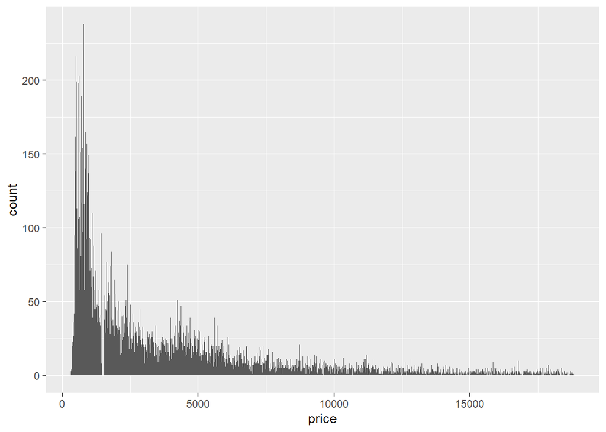

```r
ggplot(fdiamonds) +
  geom_histogram( aes(x = price), binwidth = 5)
```

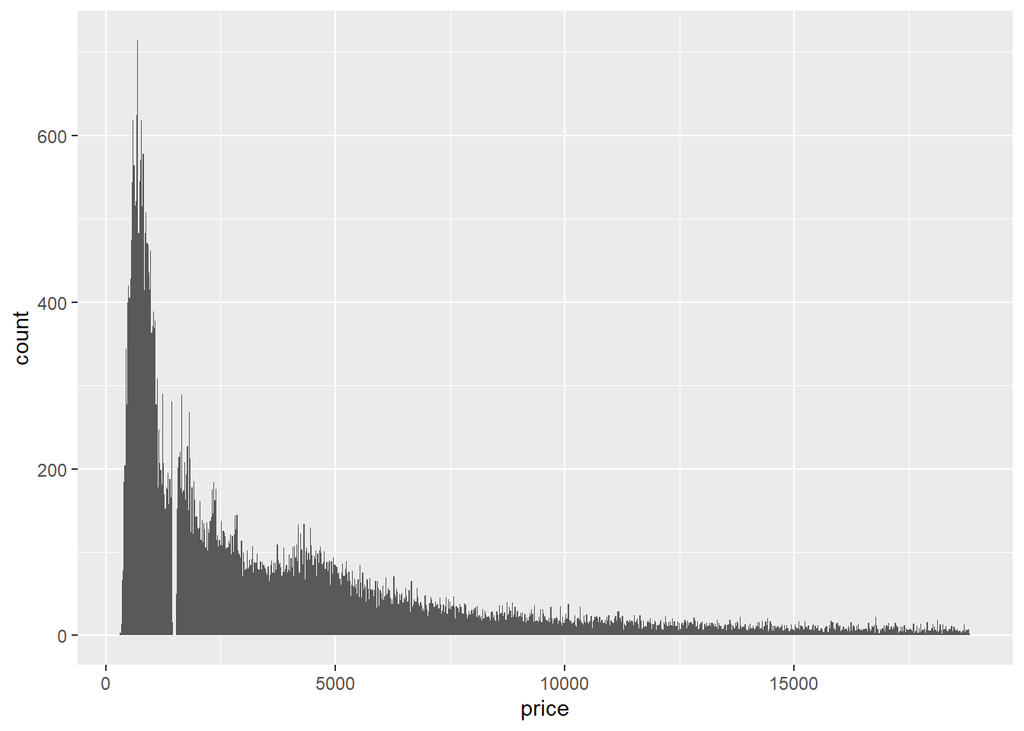

```r
ggplot(fdiamonds) +
  geom_histogram( aes(x = price), binwidth = 20)
```

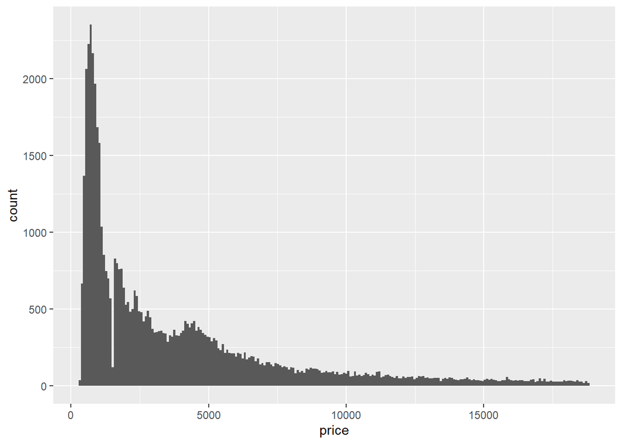

```r
ggplot(fdiamonds) +
  geom_histogram( aes(x = price), binwidth = 80)
```

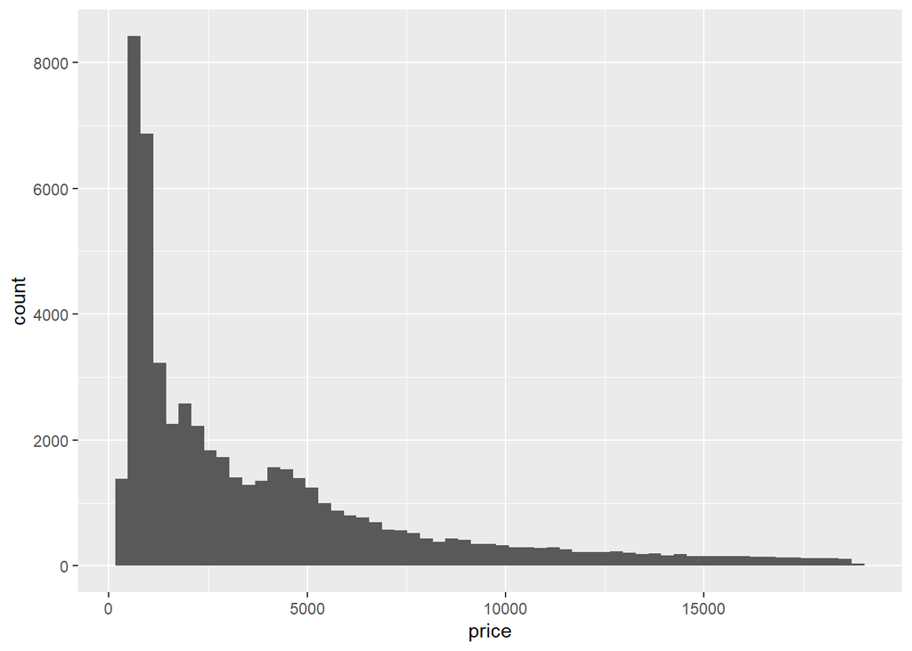

```r
ggplot(fdiamonds) +
  geom_histogram( aes(x = price), binwidth = 320)
```

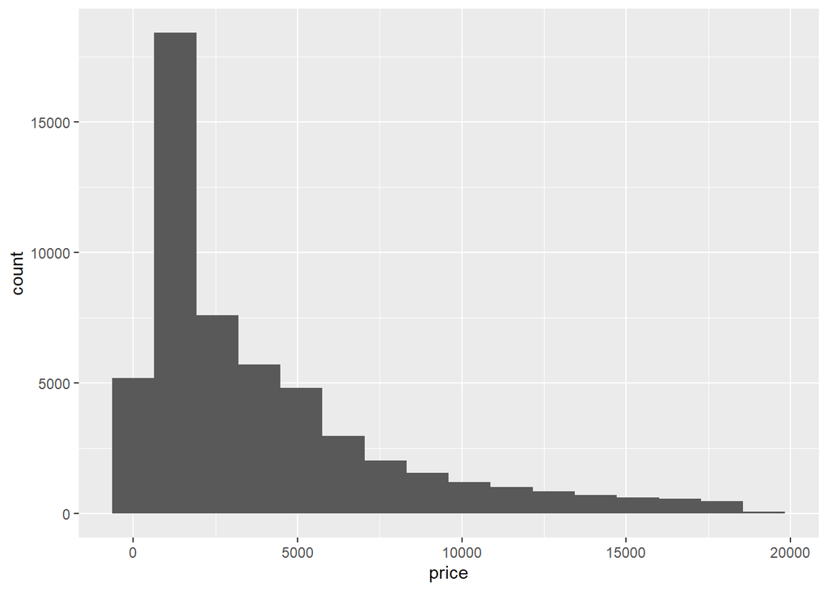

```r
ggplot(fdiamonds) +
  geom_histogram( aes(x = price), binwidth = 1280)
```

For higher binwidth we can appreciate a second smoother curve, skewed to the left, around 5k$.

1. How many diamonds are 0.99 carat? How many are 1 carat? What do you think is the cause of the difference?

```r
diamonds %>%
  filter( carat == 0.99 | carat == 1) %>%
  group_by( carat ) %>%
  summarize( n() )
```

```
## # A tibble: 2 x 2
##   carat `n()`
## * <dbl> <int>
## 1  0.99    23
## 2  1     1558
```

Probably because the diamonds are cut down to the carat and this is sort of a standard for selling them

1. Compare and contrast `coord_cartesian()` vs `xlim()` or `ylim()` when zooming in on a histogram. What happens if you leave `binwidth` unset? What happens if you try and zoom so only half a bar shows?

`coord_cartesian()` sets the limits on the coordinate system performs a visual zoom. The data is unchanged. Smooth continues past the points visible on the plot. Args: - xlim, ylim - expand = TRUE, default (coordinate system) = FALSE - clip = “on” (if off, points may be appear outside the plot)

Setting the limits on a scale converts all values outside the range to NA. es `scale_x_continuous(limits = c(325, 500))` is equivalent to call xlim() and ylim(functions) When zooming the scale, the we get 25 new bins that are the same, size on the plot, but represent smaller regions of the data space.

When zooming the coordinate system, we see a subset of original 50 bins, displayed bigger

### Exercises

1. What happens to missing values in a histogram? What happens to missing values in a bar chart? Why is there a difference?

Default for both is na.rm = FALSE, missing values are removed with a warning, if TRUE they are silently removed.

```r
flights <- nycflights13::flights

# this is the idea, expressed in dlypr
flights %>%
  mutate( cancelled = is.na(dep_time) ) %>%
  group_by( month ) %>%
  summarise( tot_cancelled = sum(cancelled),
             tot_flights = n() - tot_cancelled )
```

```
## # A tibble: 12 x 3
##    month tot_cancelled tot_flights
##  * <int>         <int>       <int>
##  1     1           521       26483
##  2     2          1261       23690
##  3     3           861       27973
##  4     4           668       27662
##  5     5           563       28233
##  6     6          1009       27234
##  7     7           940       28485
##  8     8           486       28841
##  9     9           452       27122
## 10    10           236       28653
## 11    11           233       27035
## 12    12          1025       27110
```

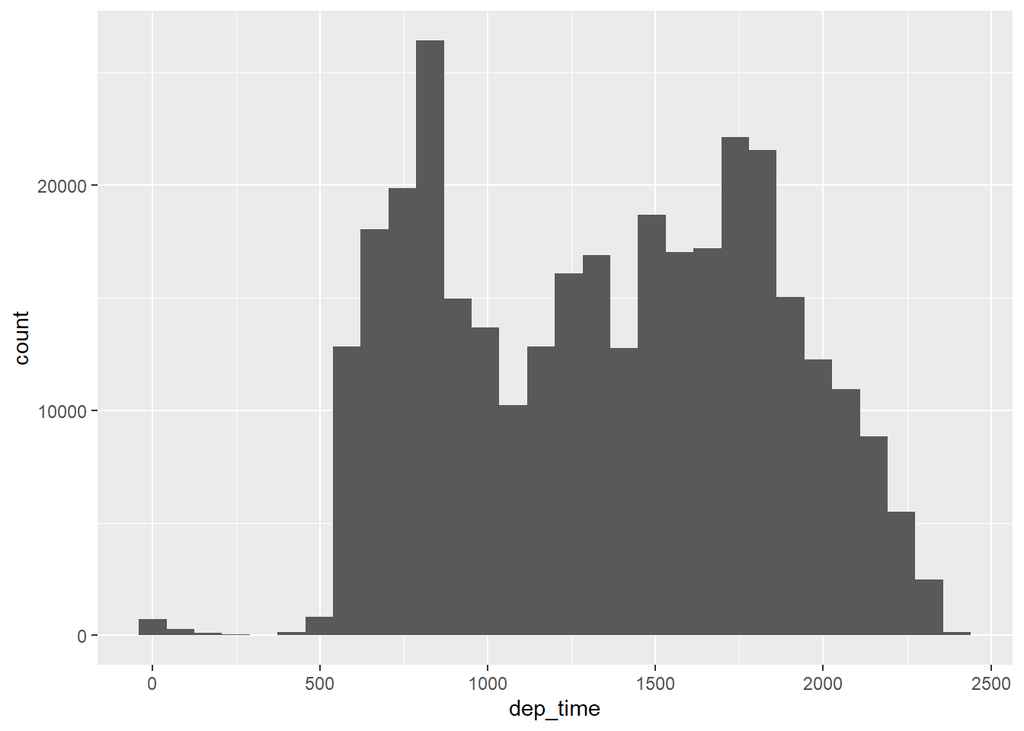

```r
ggplot(flights) +
  geom_histogram( aes(x = dep_time))
```

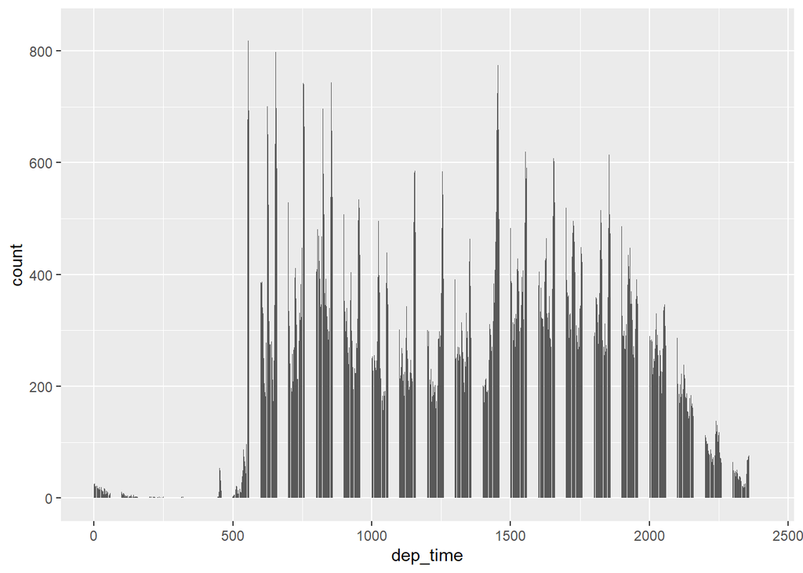

```r
ggplot(flights) +
  geom_bar( aes(x = dep_time))
```

But let’s try to set to zero between noon and 5pm and see what happens .

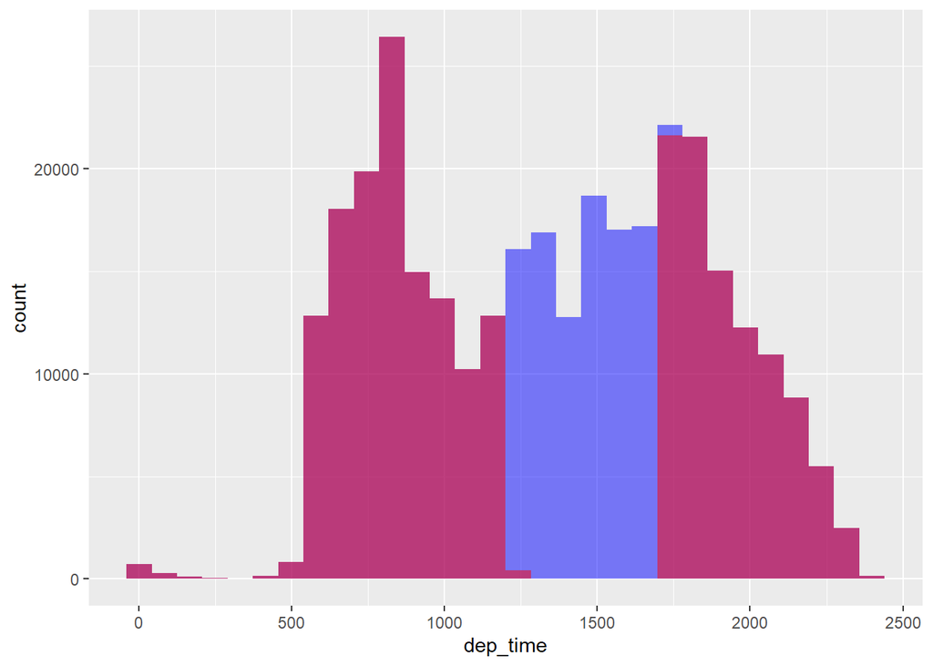

```r
flights <- nycflights13::flights
flights %>%
  mutate( dep_time_false = ifelse(dep_time  > 1200 & dep_time <= 1700,
                            yes = NA,
                            no = dep_time  )) %>%
  ggplot() +
    geom_histogram(mapping = aes( x = dep_time ), fill = "blue", alpha = 0.5) +
    geom_histogram(mapping = aes( x = dep_time_false ), fill = "red", alpha = 0.5)
```

Values set to NA are not plotted, but the two graph are similar

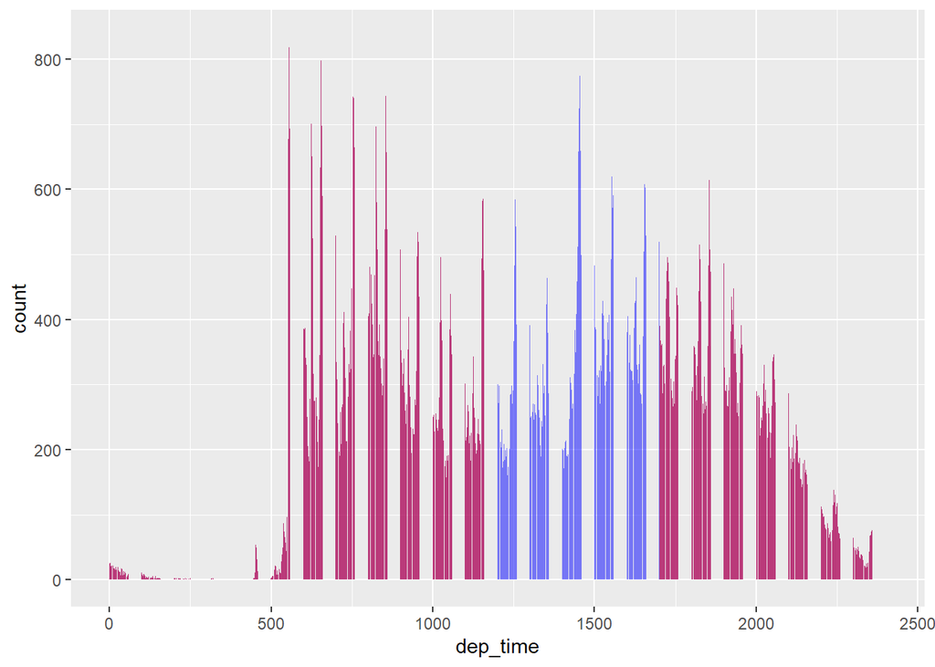

```r
flights <- nycflights13::flights
flights %>%
  mutate( dep_time_false = ifelse(dep_time  > 1200 & dep_time <= 1700,
                            yes = NA,
                            no = dep_time  )) %>%
  ggplot() +
    geom_bar(mapping = aes( x = dep_time ), fill = "blue", alpha = 0.5) +
    geom_bar(mapping = aes( x = dep_time_false ), fill = "red", alpha = 0.5)
```

geom_bar is not influenced by NAs, it simply does not plot them.

1. What does `na.rm = TRUE` do in `mean()` and `sum()`?

It removes NA Values that cause mean or sum to set to a NA result overall

### Exercises

1. Use what you’ve learned to improve the visualisation of the departure times of cancelled vs. non-cancelled flights.

```r
flights %>%
  group_by(is.na(dep_time)) %>%
  summarise(n())
```

```
## # A tibble: 2 x 2
##   `is.na(dep_time)`  `n()`
## * <lgl>              <int>
## 1 FALSE             328521
## 2 TRUE                8255
```

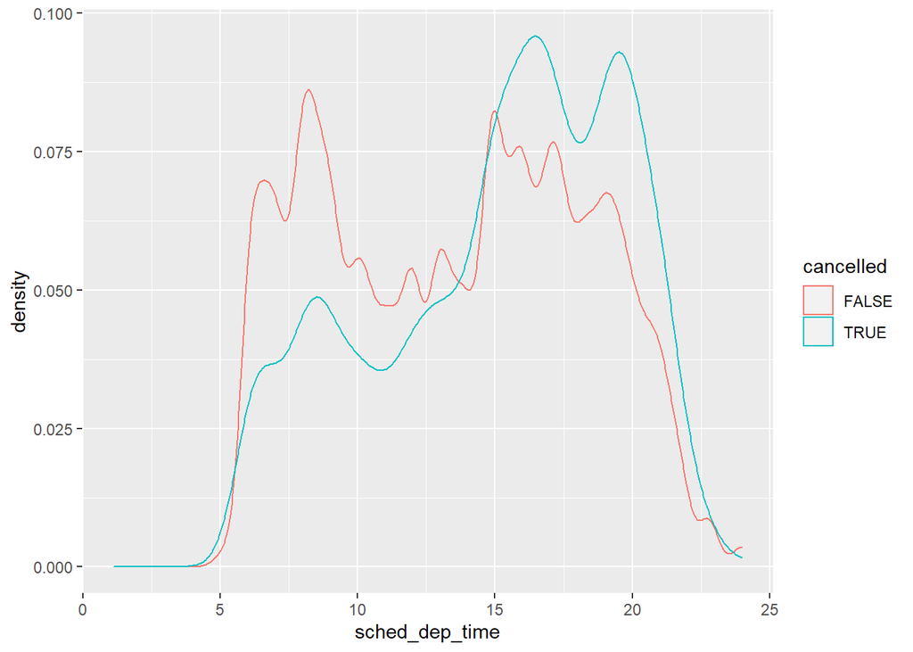

```r
flights %>%
  mutate(
    cancelled = is.na(dep_time),
    sched_hour = sched_dep_time %/% 100,
    sched_min = sched_dep_time %% 100,
    sched_dep_time = sched_hour + sched_min / 60
  ) %>%
  ggplot( aes( x = sched_dep_time,
               color = cancelled) ) +
    geom_density()
```

1. What variable in the diamonds dataset is most important for predicting the price of a diamond? How is that variable correlated with cut? Why does the combination of those two relationships lead to lower quality diamonds being more expensive?

First of all, we try to plot. I chose a bin2d since it’s a sort of bidimensional histogram to plot those two varabiables. Geom_point does not represent well data, with strong vertical bars where carat threasholds are in place.

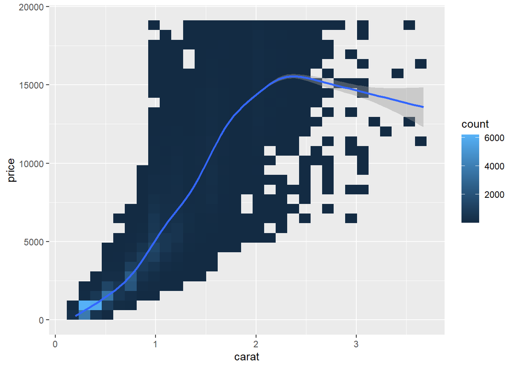

```r
ggplot(fdiamonds, aes(carat, price)) +
  geom_bin2d() +
  geom_smooth()
```

To compare carat-cut distributions, we plot them side to side. Histogram has not been used since distributions greatly differ in number of diamonds.

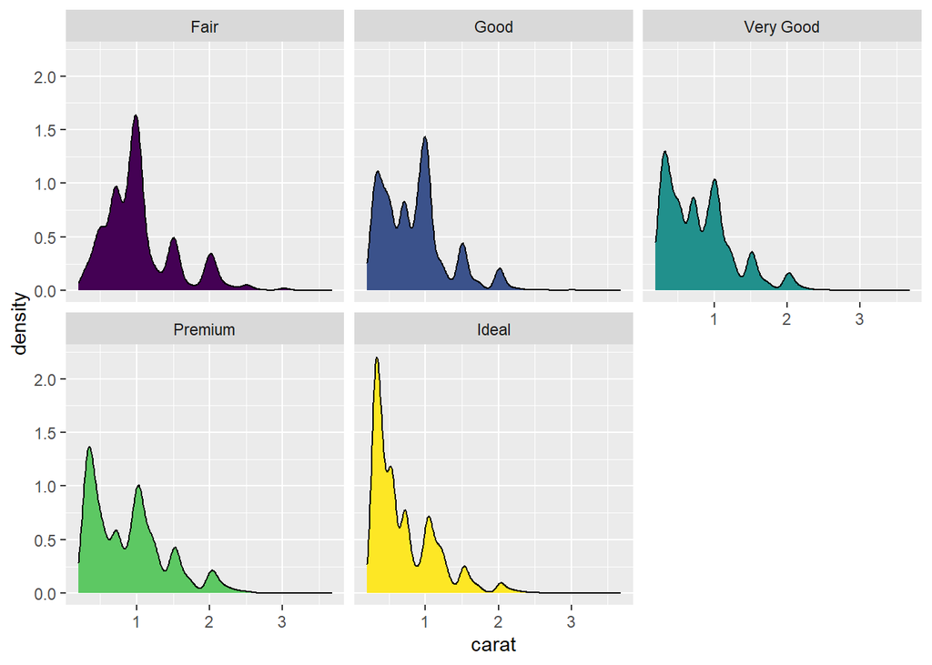

```r
ggplot(fdiamonds) +
  geom_density( aes(carat, fill = cut) ,
                show.legend = FALSE) +
  facet_wrap( ~cut )
```

As we can see there is a strong binding between the two variable, where fair diamonds seem to be with more carats. More specifically, distributions greatly differ from one another.

```
Q: Why does the combination of those two relationships lead to lower quality
diamonds being more expensive?
We can see that price increases with carat, but also a higher quality is more difficult to achieve. So, most "ideal" diamonds are low-carat, while a greater number of worse cut diamonds are high-carat. Those two conflicting trends create the bias with lower quality diamonds are more expensive.
```

1. Exchange x variable and y variable in a vertical boxplot, and create a horizontal boxplot. How does this compare to using `coord_flip()`?

Standard boxplot

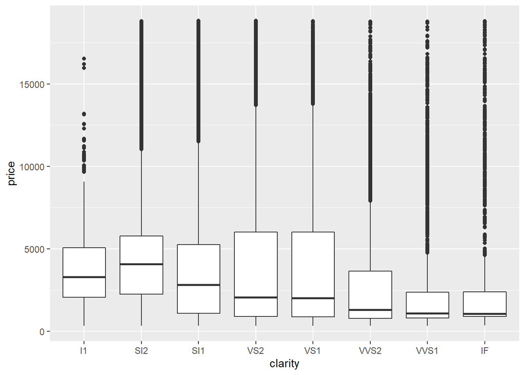

```r
ggplot(fdiamonds) +
  geom_boxplot( aes( x = clarity, y = price ))
```

Exchange x and y boxplot

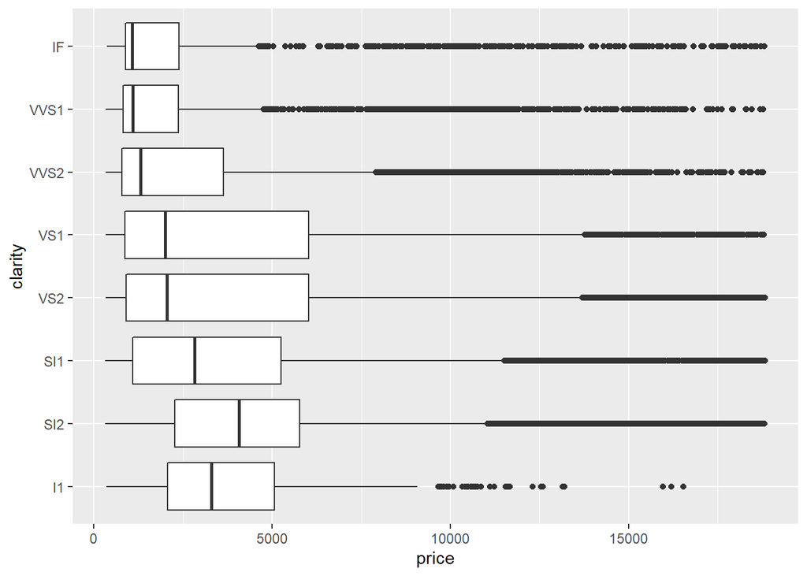

```r
ggplot(fdiamonds) +
  geom_boxplot( aes( x = price, y = clarity ))
```

Using coord_flip()

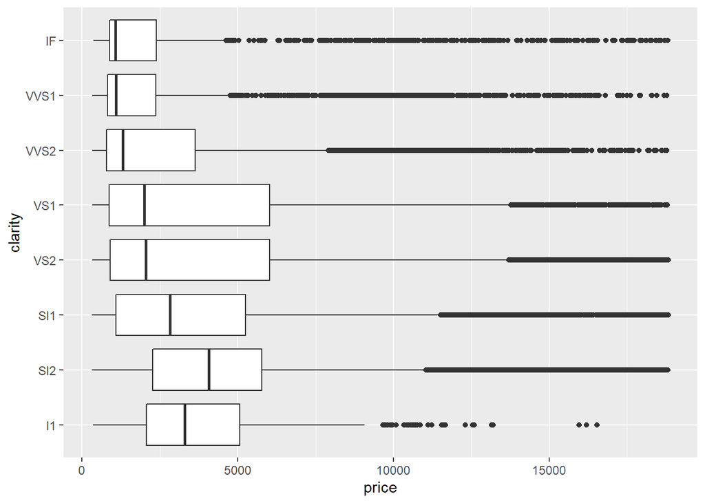

```r
ggplot(fdiamonds) +
  geom_boxplot( aes( x = clarity, y = price )) +
  coord_flip()
```

No difference can be seen from data, they are equivalent expressions

1. One problem with boxplots is that they were developed in an era of much smaller datasets and tend to display a prohibitively large number of “outlying values”. One approach to remedy this problem is the letter value plot. Install the lvplot package, and try using `geom_lv()` to display the distribution of price vs cut. What do you learn? How do you interpret the plots?

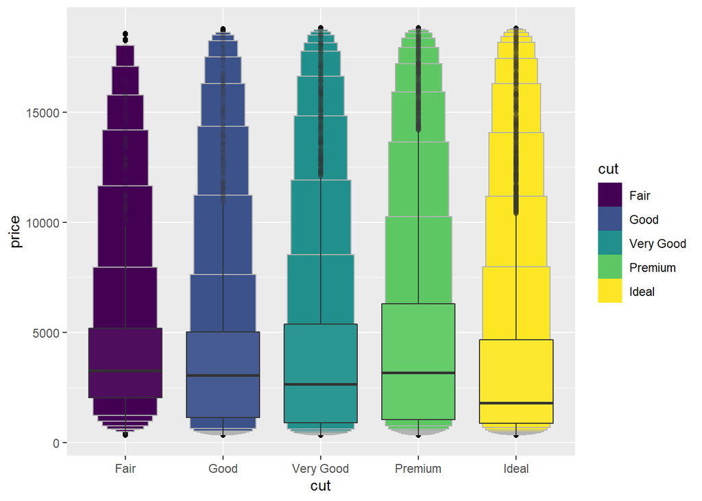

```r
library(lvplot)

ggplot(fdiamonds) +
  geom_lv( aes(cut, price,
               fill = cut)) +
  geom_boxplot( aes(cut, price),
                alpha = 0.05)
```

Fattest box is between letter values that are (approximate) quartiles, next till 8-tiles, then 16-tiles and so on. Letter stops when confidence intervals overlap with next letter, leaving outliers from then on.

Regarding interpreation, eache box represent as many data points as the sum of all subsequent ones.

1. Compare and contrast `geom_violin()` with a facetted `geom_histogram()`, or a coloured `geom_freqpoly()`. What are the pros and cons of each method?

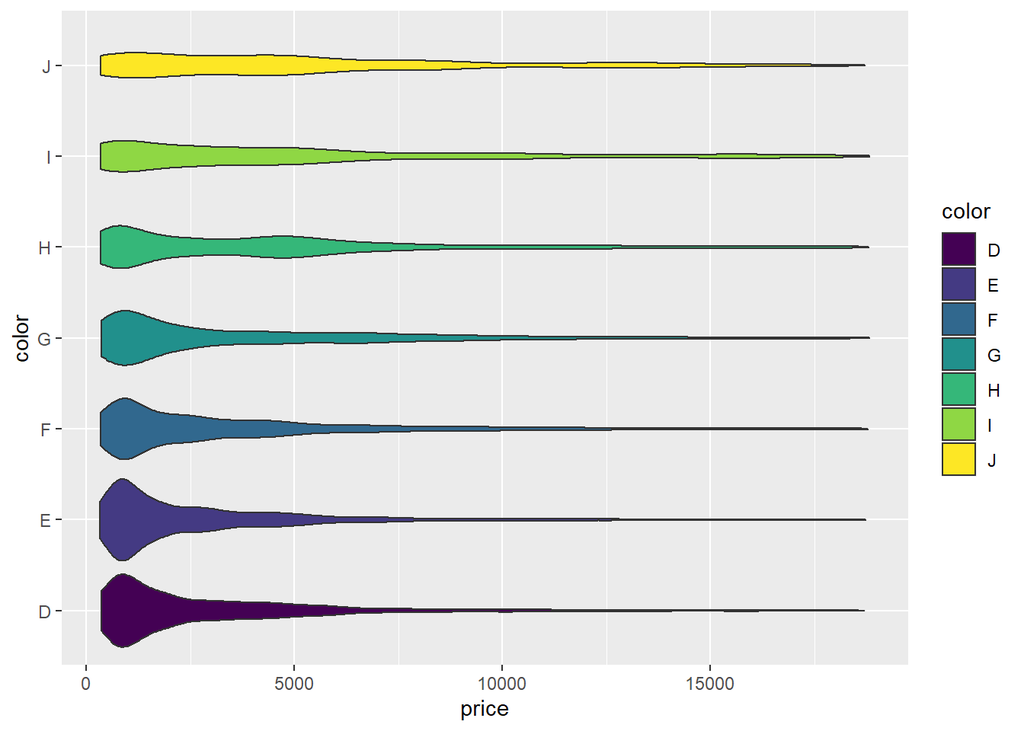

```r
ggplot(fdiamonds, aes(x = price, y = color, fill = color)) +
  geom_violin()
```

Pros: - easily compare really different distributions - works also if they have different count (uses the density function)

Cons: - the more categories, the more difficult the plot is to interpret

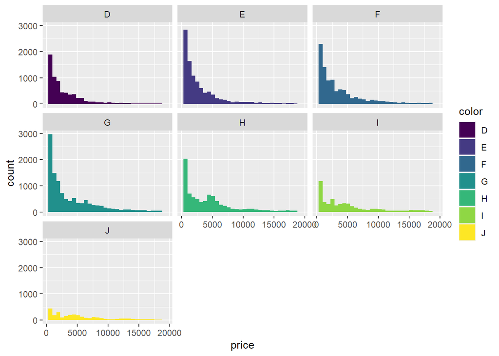

```r
ggplot(fdiamonds, aes(x = price, fill = color)) +
  geom_histogram() +
  facet_wrap( ~color )
```

Pros: - useful even with a lot of categories - very easy to compare if they have similar count number

Cons: - density function is not standard - small difference cannot be seen if the plot are not stacked over each other

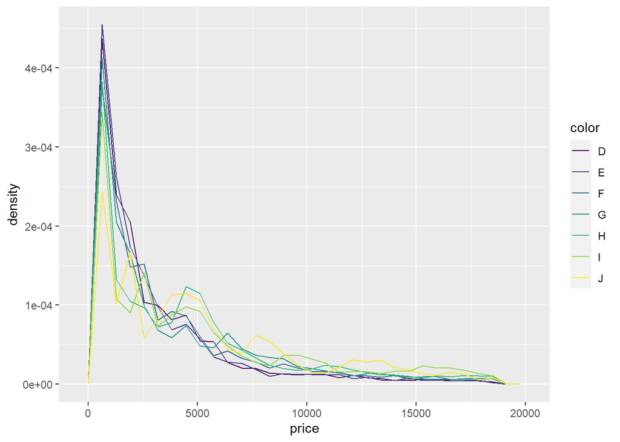

```r
ggplot(fdiamonds, aes(x = price,
                      y = ..density..,
                      color = color)) +
  geom_freqpoly()
```

Pros: - easy to compare small differences

Cons: - the more categories, the more difficult to read is the plot - the more similar are distributions, the same

1. If you have a small dataset, it’s sometimes useful to use `geom_jitter()` to see the relationship between a continuous and categorical variable. The ggbeeswarm package provides a number of methods similar to `geom_jitter()`. List them and briefly describe what each one does.

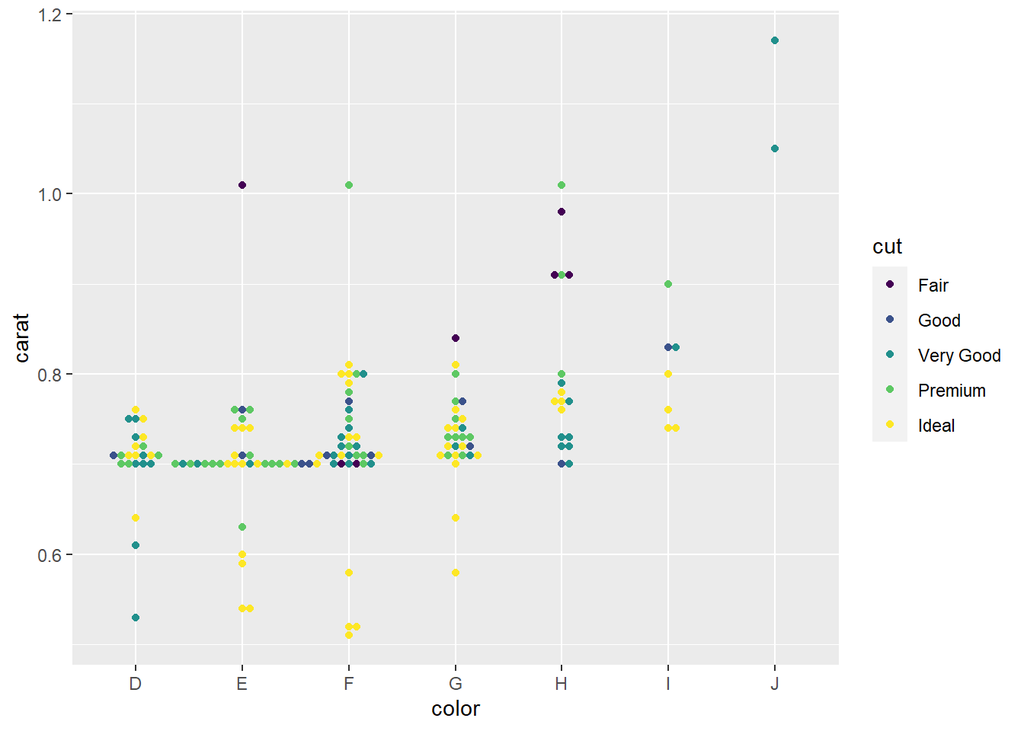

```r
library(ggbeeswarm) #has two main functions

# geom_beeswarm
ggplot(fdiamonds[100:250,],
       aes( y = carat,
            x = color,
            color = cut)) +
  geom_beeswarm()
```

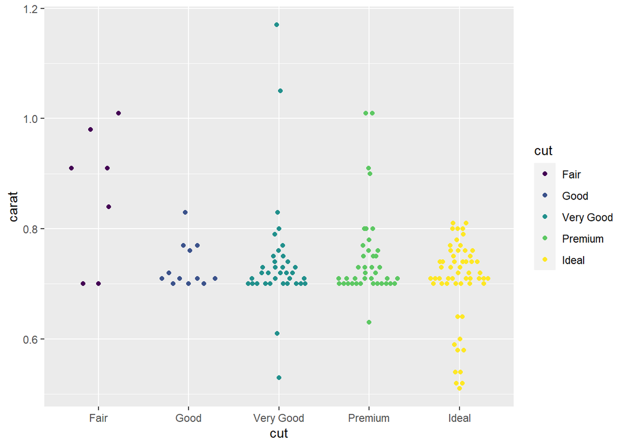

```r
# geom_quasirandom
ggplot(fdiamonds[100:250,],
       aes( y = carat,
            x = cut,
            color = cut)) +
  geom_quasirandom()
```

### Exercises

1. How could you rescale the count dataset above to more clearly show the distribution of cut within colour, or colour within cut?

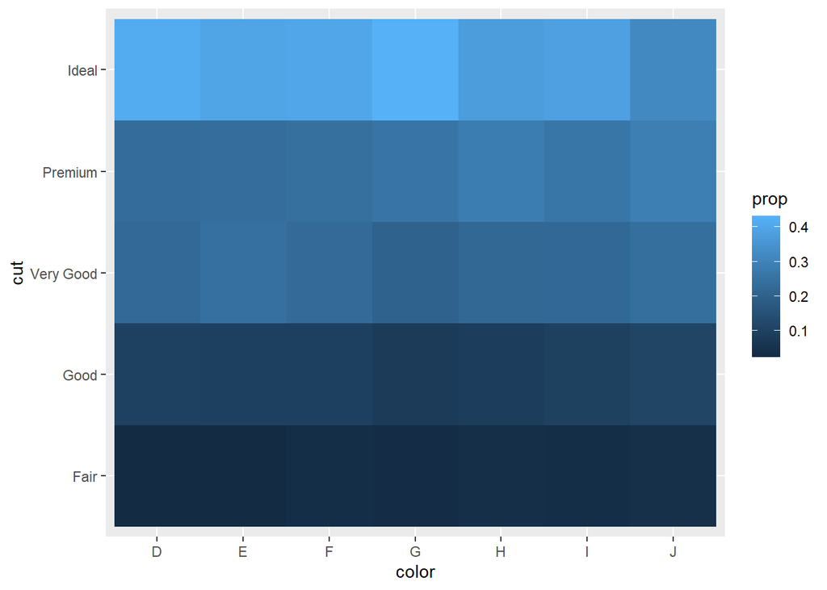

```r
# cut within colour
fdiamonds %>%
  group_by(color, cut) %>%
  summarize( n = n() ) %>%
  mutate( prop = n / sum(n) ) %>%
  ggplot() +
    geom_tile( aes( x = color,
                    y = cut,
                    fill = prop))
```

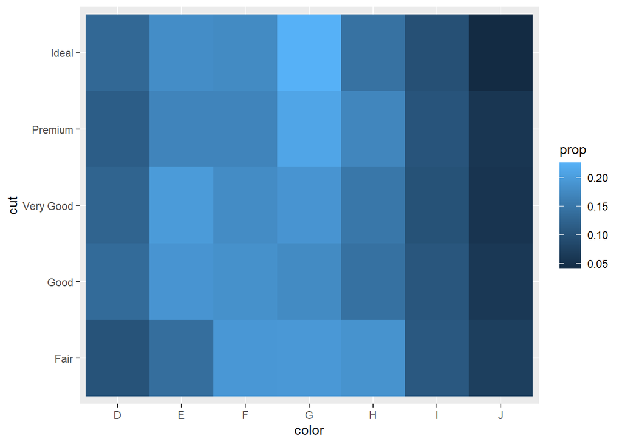

```r
# colour within cut
fdiamonds %>%
  group_by(cut, color) %>%
  summarize( n = n() ) %>%
  mutate( prop = n / sum(n) ) %>%
  ggplot() +
    geom_tile( aes( x = color,
                    y = cut,
                    fill = prop))
```

1. Use `geom_tile()` together with dplyr to explore how average flight delays vary by destination and month of year. What makes the plot difficult to read? How could you improve it?

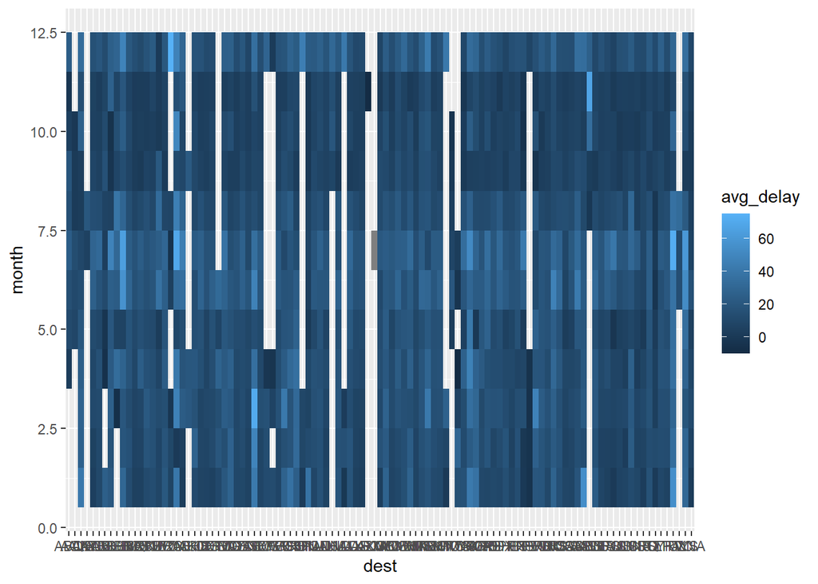

```r
nycflights13::flights %>%
  group_by(dest, month) %>%
  summarize( avg_delay = mean(dep_delay, na.rm = TRUE)) %>%
  ggplot() +
    geom_tile( aes( x = dest,
                    y = month,
                    fill = avg_delay))
```

The plot is difficult to read because: - x and y are switched - data bars are stretched - destination are ordered according to the alphabet - blue shades are not informative

We should: - switch x and y - fix coordinates (facet the wrap to allow easier reading) - order from the worst to the best - choose better color palette

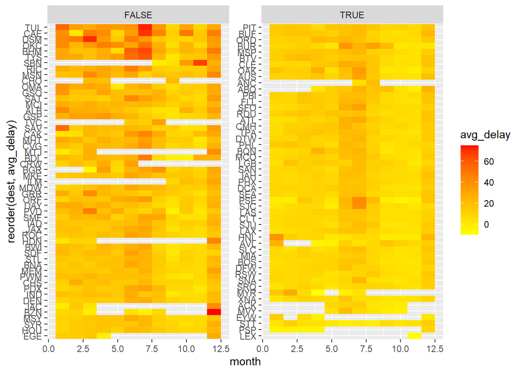

```r
nycflights13::flights %>%
  group_by(dest, month) %>%
  summarize( avg_delay = mean(dep_delay, na.rm = TRUE)) %>%
  mutate( dest_delay = mean(avg_delay)) %>%
  filter( dest != "LGA") %>%
  ggplot() +
    geom_tile( aes( x = month,
                    y = reorder(dest, avg_delay),
                    fill = avg_delay)) +
    facet_wrap( ~ dest_delay < median(dest_delay),
                scales = "free_y") +
    scale_fill_gradient(low="yellow", high="red")
```

1. Why is it slightly better to use `aes(x = color, y = cut)` rather than `aes(x = cut, y = color)` in the example above?

### Exercises

1. Instead of summarising the conditional distribution with a boxplot, you could use a frequency polygon. What do you need to consider when using `cut_width()` vs `cut_number()`? How does that impact a visualisation of the 2d distribution of `carat` and `price`?

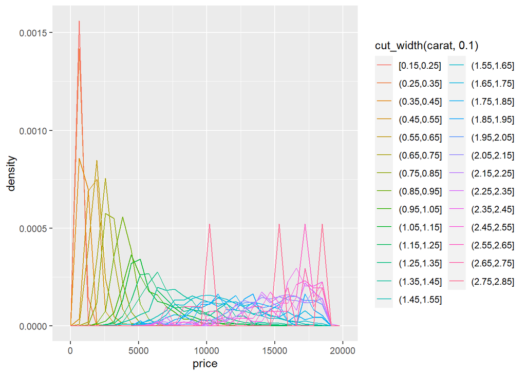

```r
smaller <- diamonds %>%
  filter(carat < 3)

ggplot(data = smaller,
       mapping = aes(x = price,
                     y = ..density..)) +
  geom_freqpoly(mapping = aes(color = cut_width(carat, 0.1)))
```

Density can be used when we cut by width, since we are interested in seeing how they are distributed across the spectrum.

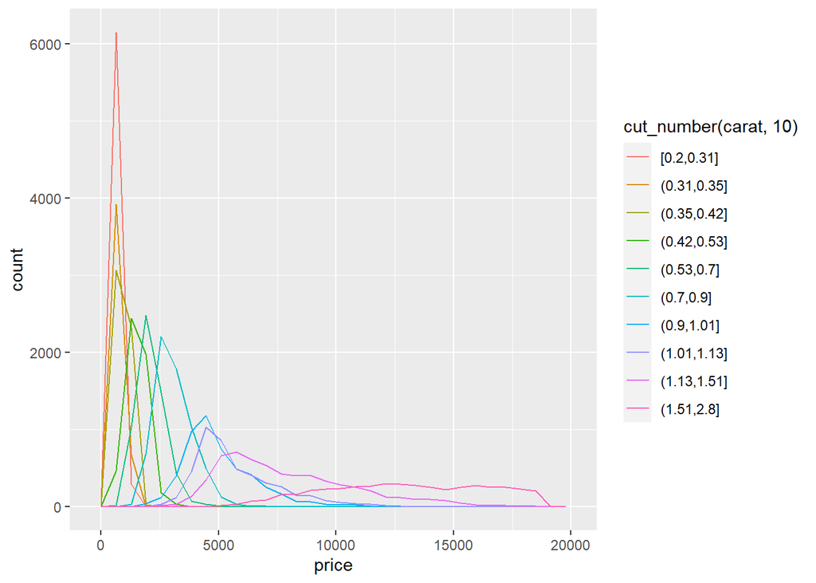

```r
ggplot(data = smaller,
       mapping = aes(x = price)) +
  geom_freqpoly(mapping = aes(color = cut_number(carat, 10)))
```

When we cut by number we want to see how stretched is the distribution, without any ..density.. correction

1. Visualise the distribution of carat, partitioned by price.

First we try with the BW-plot

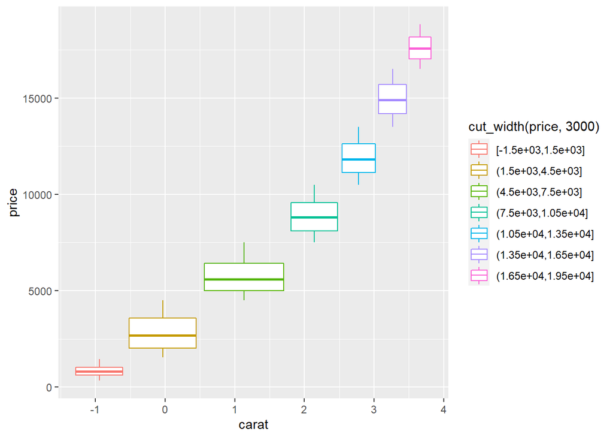

```r
ggplot(data = smaller,
       mapping = aes(x = carat,
                     y = price)) +
  geom_boxplot(mapping = aes(color = cut_width(price, 3000)),
               varwidth = TRUE)
```

Then we opt for a violin

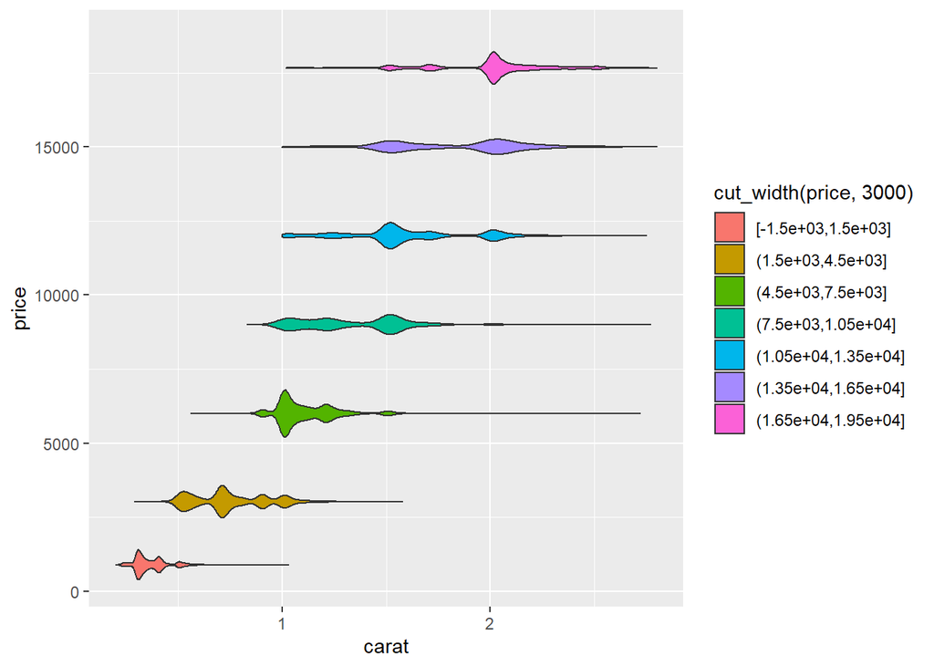

```r
ggplot(data = smaller,
       mapping = aes(y = carat,
                     x = price)) +
  geom_violin(mapping = aes(fill = cut_width(price, 3000))) +
  coord_flip()
```

1. How does the price distribution of very large diamonds compare to small diamonds? Is it as you expect, or does it surprise you?

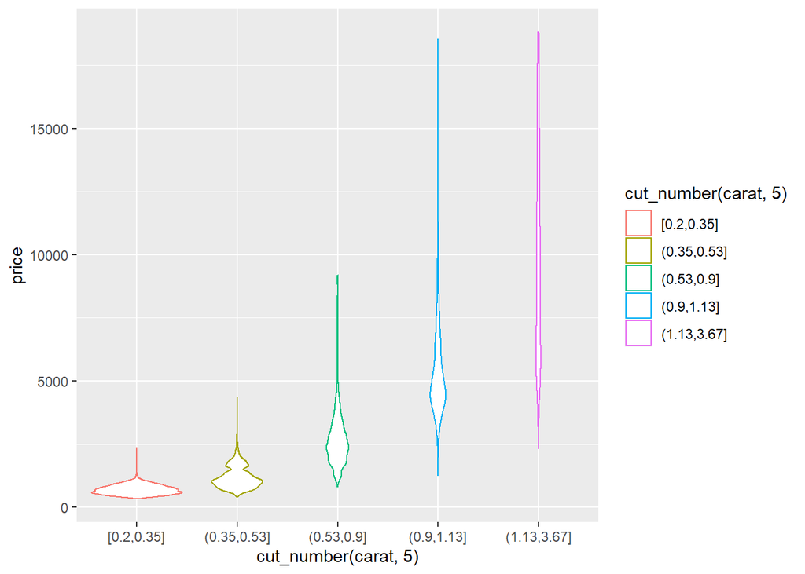

```r
ggplot(fdiamonds,
       aes( x = cut_number(carat, 5),
            y = price)) +
  geom_violin( aes( color = cut_number(carat, 5)))
```

As we can see, lowest quintile is way less stretched than the bigger one (which is also obviously more expensive), variance increases with carats probably because quality on other features can play a bigger role.